# Maps for Hughes spartina sourcing EVA 2026 submission

Sarit Truskey

Created 2026-02-04 | Last updated 2026-03-12

This Rmd file generates the maps included in the Hughes et al. 2026 *Spartina* sourcing manuscript submitted to Evolutionary Applications.

I’ve included detailed annotations as a walk-through to understanding what is going on in this script and to facilitate further map making for Hughes Lab members (particularly for fine-scaled maps of Massachusetts coastal areas but also more widely applicable). Happy mapping!

**Before running**: Set your working directory to the Hughes_EVA2026_Spartina_Map/ folder. The directory check in the first chunk will confirm you’re in the right place.

## Outline

Randall asked for map similar-ish to Fig 1a of Truskey et al. 2025. Specifically,

- a base map with approximate triangles to indicate where the 3 *Spartina* nurseries in Massachusetts (MA), New Jersey (NJ), and Maryland (MD),
- and then an inset map of the local MA marshes that shows the 9 subsites at Belle Isle (diamonds), Rumney (circles), and Rowley (squares) where separate collections were also taken.

Collections for the two focal species *Spartina alterniflora* (SA) and *Spartina patens* (SP) were effectively from most of the same subsites, so Randall suggests just using SA coordinates. We could then differentiate the only two unique subsites (Law’s is SA only and Stackyard South is SP only) as needed. Analyses and other plots are at the site-level, so seeing a super resolved distribution of all the subsites might not be needed. I’ll go ahead and generate these subsite-level plots just in case though.

Colors for plotting provided by Serena to match up with other figs already made:

| group | color |
| --- | --- |
| Nursery (MA) | thistle4 |
| Nursery (NJ) | thistle3 |
| Nursery (MD) | thistle2 |
| Rumney | paleturquoise4 |
| Rowley | paleturquoise3 |
| Belle Isle | paleturquoise |

## Data Provenance

- Spatial outline shapefiles for Massachusetts were obtained from MassGIS Data [(link to 25k state polygon and line datalayers)](https://www.mass.gov/info-details/massgis-data-state-outlines)
- Site- and subsite-level data from local marshes were compiled by Hughes lab members.

### Load libraries

```r
# you can install any missing packages here
# install.packages(c(
#   "sf",
#   "ggplot2",
#   "rnaturalearth",
#   "rnaturalearthdata",
#   "maps",
#   "dplyr",
#   "ggspatial"
# ))

library(sf)
library(ggplot2)
library(rnaturalearth)
library(maps)
library(dplyr)
library(ggspatial) # for adding scale bars to inset zoomed in plots
```

## A. Make base map with nursery and local marsh source sites

### A1. Get background layers for base map

```r
# US state outlines (as sf)
states <- st_as_sf(map("state", plot = FALSE, fill = TRUE))

# world polygons provided here as an optional alternative background layer
# note there can be slight mismatches between world and states polygons so use one consistently for any given map figure
# world <- ne_countries(scale = "medium", returnclass = "sf")
```

### A2-4. Read in and add location data

```r
# Read in local marsh subsite data
ma_subsites_locs <- read.csv(
  file.path("data","Table 1 for Belle Isle ms - Sheet1.csv"),
  stringsAsFactors = FALSE) # stringsAsFactors = FALSE ensures character columns (like site names) are read as plain text rather than factors, which can cause some unexpected behavior in filtering and plotting
names(ma_subsites_locs) <- tolower(names(ma_subsites_locs))
head(ma_subsites_locs)
```

```
##           species         site      subsite latitude longitude
## 1 S. alterniflora   Belle Isle       L-Berm   42.387    70.990
## 2 S. alterniflora   Belle Isle Rosie's Pond   42.387    70.998
## 3 S. alterniflora   Belle Isle          Key   42.391    70.986
## 4 S. alterniflora Rumney Marsh          Far   42.437    70.996
## 5 S. alterniflora Rumney Marsh     Hamilton   42.443    70.990
## 6 S. alterniflora Rumney Marsh      Terrace   42.440    71.011
##   date.of.seed.collection source.population.n greenhouse.population.n
## 1            Sept 14 2022                  20                       0
## 2            Sept 14 2022                  20                      20
## 3            Sept 14 2022                  20                       0
## 4            Sept 15 2022                  20                      20
## 5            Sept 15 2022                  20                      20
## 6            Sept 15 2022                  20                      20
```

```r
# if longitude not listed as negative (i.e., in provided data), set to negative here or it won't appear in base maps...
ma_subsites_locs$longitude <- -ma_subsites_locs$longitude

# Create a single "local marsh sites" point
# getting the mean across all marsh subsites; this is just to place a single local marsh marker...
marsh_centerpt <- ma_subsites_locs %>% #in case you don't work with dplyr much, this is a pipe operator which basically means “take this dataset provided, then do the following...”
  summarize( #in this case, using summarize to parse data down to single row with the folowing columns...
    lat = mean(latitude, na.rm = TRUE), # lat with a mean latitude value from the latitude column in ma_subsites_locs
    lon = mean(longitude, na.rm = TRUE) #same for long
  ) %>%
  mutate(type = "marsh", site_label = "marsh") # then add new columns (type and site_label) to this new dataframe with the values "marsh"

#the output is a dataframe called marsh_centerpt with a single row and columns c(lat, lon, type, site_label) with values as described
marsh_centerpt # we'll use this to center a rectangle around the local marsh sites
```

```
##        lat      lon  type site_label
## 1 42.52483 -70.9425 marsh      marsh
```

```r
# Nursery locations
# I just got approximate ones off google maps that reflected the vague area in which the nurseries were located and created a dataframe to house those values
nursery_sites <- data.frame(
  type = "nursery",
  site_label = c("MA", "NJ", "MD"),
  lat = c(42.400851, 40.027180, 38.645799),
  lon = c(-72.331368, -74.493395, -75.998390)
)

# Combine the data from the single local marsh representative site + nursery sites
(all_sites_locs <- bind_rows(nursery_sites, marsh_centerpt))
```

```
##      type site_label      lat       lon
## 1 nursery         MA 42.40085 -72.33137
## 2 nursery         NJ 40.02718 -74.49340
## 3 nursery         MD 38.64580 -75.99839
## 4   marsh      marsh 42.52483 -70.94250
```

```r
# looks good
```

### A5. Create base map plot

Going to break this down with detailed annotations as the first map plot

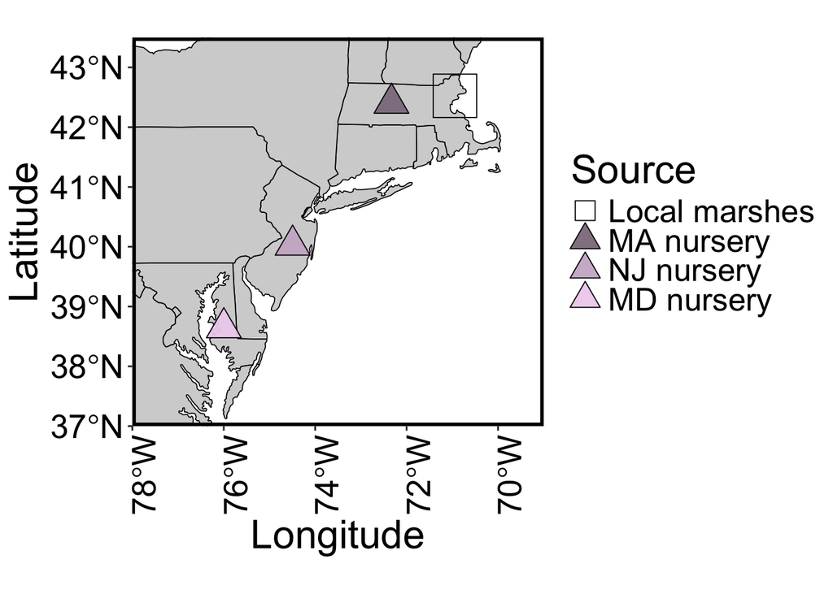

```r
base_map <- ggplot() +
  geom_sf( # using state polygons and outlines from states object imported above
    data = states,
    fill = "lightgrey", # land should be lightgrey fill
    color = "black", # state borders and coastline should be outlines in black
    linewidth = 0.3) +
  coord_sf( # this controls map extent: adjust these numbers as wanted to make the plot more or less zoomed in to the sites
    xlim = c(-78, -69), # x is longitude (you can adjust these as desired)
    ylim = c(37, 43.5), # y is latitude (you can adjust these as desired)
    expand = FALSE) +
  geom_point( # add points for sources
    data = all_sites_locs,
    aes(x = lon, y = lat,
        shape = type, # want shape to change according to nursery or marsh
        fill = site_label, # want color to change to try to match the current fig 1 (add in colors for fill with scale_fill_manual)
        size = type), # want to make the marsh site larger to try to encompass all of the source areas of local marsh subsites
    color = "black", # setting outline of the shapes black here
    alpha = 0.95 # making them a tiny bit see-through (for more see-through, decrease alpha value)
  ) +
  scale_shape_manual( # set shape values
    values = c(marsh = 0, nursery = 24), # empty square, filled-in triangle;
    guide = "none") +  # guide = 'none' means no guide for legend (going to make a single guide that covers it manually below)
  scale_size_manual( # set size values
    values  = c(marsh = 12, nursery = 7), # making marsh larger
    guide = "none") +
  scale_fill_manual( # set fill color values; going to use the fill guide as the single all-things-covered guide so adding a bit extra here...
    values  = c( # this sets the colors that appear in the key
      marsh = "transparent",
      MA = "thistle4",
      NJ = "thistle3",
      MD = "thistle2"),
    breaks = c("marsh", "MA", "NJ", "MD"), # this controls the order in which the values are listed
    labels = c( # this controls the actual name that will appear in the key
    MA   = "MA nursery",
    NJ   = "NJ nursery",
    MD   = "MD nursery",
    marsh = "Local marshes" #confirmed with Randall that this should be 'Local marshes'
  ),
  name = "Source") + # this renames the key itself
  guides( # going to customize guide for fill a bit more here
    fill = guide_legend(
      override.aes = list( # this forces the legend keys to render under the following arguments as opposed to the defaults...
        shape = c(22, 24, 24, 24), # render with these specific shapes (note, needs to be provided in order specified with breaks if breaks was provided)
        color = "black", # black outline
        size = 6) # make a bit bigger than default
    )) +
  labs(x = "Longitude", # add x and y-labels...can also add guide labels here too
       y = "Latitude") +
  theme( # the following are additional specifications more about aesthetics than anything...
    panel.grid = element_line(color = "transparent"),
    panel.background = element_rect(fill = "white"),
    text = element_text(size = 24, color = "black"), # make text bigger and color should be black
    axis.text.x = element_text(angle = 90, hjust = 1, size = 20, color = "black"), # sets x-axis values text size and angle flips them 90 degrees
    axis.text.y = element_text(size = 20, color = "black"),
    panel.border = element_rect(color = "black", fill=NA, linewidth=2) # adds a panel border here...i like them for maps but up to you!
  )

base_map
```

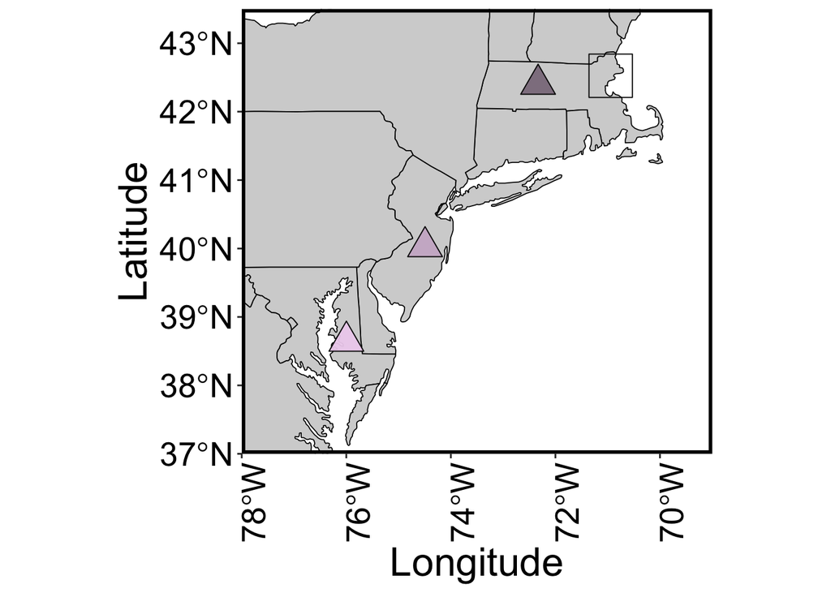

```r
base_map_nolegend <- base_map + theme(legend.position = "none") # remove the guide

base_map_nolegend
```

### A6. Export to pdf

```r
# save plots as pdfs

ggsave(
  filename =
    file.path(
      "map_figs", #output directory with root directory (see READme for expected directory structure if this is confusing)
      "base_map.pdf"), # last is the name for the output file, in this case base_map.pdf
  plot = base_map,
  width = 8, height = 6) # specify dimensions for pdf here

# also want to output second plot that excludes the legend
ggsave(
  filename = file.path( "map_figs","base_map_nolegend.pdf"),
  plot = base_map_nolegend,
  width = 8, height = 6)
```

## B. Inset maps for local marsh source subsites

### B1. Read in MassGIS coastline/shoreline layer

I am using the shapefiles for Massachusetts coastline provide by MassGIS [(link)](https://www.mass.gov/info-details/massgis-data-state-outlines)

- Note, you need to download, unzip, and keep the contents of the full file with all shapefiles and not just file with .shp extension. See Data setup in README for further download instructions. If you are getting cannot open errors from st_read() below an issue with not having all the required shapefiles is almost certainly why.
- Secondary note, you can make similar fine-scale maps of other areas by just subbing in shapefiles for those areas. A link to Rhode Island shapefiles is included in README.

```r
# Check that shapefiles are where we expect them to be and, if not, provide user with a readout of whether one is missing. This isn't something you need to add to future scripts of your own, but I have added here as a troubleshooting step for why st_read() may not be working for you.
shp_path <- file.path("data", "outline25k", "OUTLINE25K_ARC.shp")
pol_path  <- file.path("data", "outline25k", "OUTLINE25K_POLY.shp")

missing_shp <- c(shp_path, pol_path)[!file.exists(c(shp_path, pol_path))]

if (length(missing_shp) > 0) { # checks whether the two shp files provided at the file paths above exist, otherwise will provide the following message
  stop(
    "MassGIS shapefile(s) not found:\n",
    paste(" -", missing_shp, collapse = "\n"), "\n",
    "Download from: https://www.mass.gov/info-details/massgis-data-state-outlines\n",
    "Unzip the outline25k download such that ALL contents should now be in data/outline25k/"
  )
}

# Read in the shapefiles now that we have confirmed they are where we expect them to be

# The first is the coastline arc file (outlines only); provide st_read function the path to the arc shp file
ma_outline <- st_read(shp_path) |> #this base R pipe (|>) then passes the output of st_read() to the next function
  st_transform(4326) # st_transform() is important in converting the shapefile into a new crs (coordinate reference system), specifically '4326' reprojects to lat/lon
# The second is the land polygon file that is helpful if you want to fill the outlines in (I like using grey backgrounds for land to differentiate from coastal water)
ma_outline_poly <- st_read(pol_path) |> st_transform(4326)
```

### B2. Get subsite location points for plotting

Randall suggested using SA pts then adding the single SP-only pt and a label to the SA-only pt, so I’m just going to do that. Not sure whether individually differentiating subsite pts is important…would be a lot of colors so probably better to do with numbers for now. Adding subsite numbers to data to be able to do this in plotting.

```r
# Get subsite points to add to inset map
ma_subsites_locs  # already loaded from basemap
```

```
##            species               site         subsite latitude longitude
## 1  S. alterniflora         Belle Isle          L-Berm   42.387   -70.990
## 2  S. alterniflora         Belle Isle    Rosie's Pond   42.387   -70.998
## 3  S. alterniflora         Belle Isle             Key   42.391   -70.986
## 4  S. alterniflora       Rumney Marsh             Far   42.437   -70.996
## 5  S. alterniflora       Rumney Marsh        Hamilton   42.443   -70.990
## 6  S. alterniflora       Rumney Marsh         Terrace   42.440   -71.011
## 7  S. alterniflora Rowley Great Marsh       Stackyard   42.745   -70.832
## 8  S. alterniflora Rowley Great Marsh           Law's   42.748   -70.843
## 9  S. alterniflora Rowley Great Marsh          Patmos   42.748   -70.840
## 10       S. patens         Belle Isle          L-Berm   42.388   -70.991
## 11       S. patens         Belle Isle    Rosie's Pond   42.388   -70.999
## 12       S. patens         Belle Isle             Key   42.391   -70.986
## 13       S. patens       Rumney Marsh             Far   42.437   -70.995
## 14       S. patens       Rumney Marsh        Hamilton   42.443   -70.991
```

[output cut: 23 more lines]

```r
# Keep all S. alterniflora (SA) rows
sa_pts <- ma_subsites_locs %>%
  filter(species == "S. alterniflora") %>% # keep only rows where species is SA
  mutate(species_used = "SA") #add a shorthand column to this df sa_pts called 'species_used' with the value "SA"

# Add Stackyard South from S. patens (SP; this is the SP only site that we want to keep in inset maps)
sp_stackyard_south <- ma_subsites_locs %>%
  filter(species == "S. patens", subsite == "Stackyard South") %>%
  mutate(species_used = "SP")

# Combine the subsites for plotting + create plotting columns
# we want shape to convey marsh sites
# want to add text to subsites that are SA or SP only (don't end up using these labels but kept here anyway)
# add subsite numbers to subsites within each marsh site
subsites_plot_locs <- bind_rows(sa_pts, sp_stackyard_south) %>% #sa rows first, sp only site at end
  mutate( # add the following columns with specified values...
    site_shape = case_when( # if else type function, where site is equal to blank ~ set new column site_shape equal to blank; if condition for site not provided (TRUE) ~ keep site value
      site == "Belle Isle" ~ "Belle Isle",
      site == "Rumney Marsh" ~ "Rumney",
      site == "Rowley Great Marsh" ~ "Rowley",
      TRUE ~ site
    ),
    subsite_display = case_when(
      subsite == "Law's" ~ "Law's (SA only)",
      subsite == "Stackyard South" ~ "Stackyard South (SP only)",
      TRUE ~ subsite
    )
  ) %>%
  group_by(site_shape) %>% # want to add number within site; so group by site here (or site_shape)
  mutate(site_num = row_number()) %>% #take row_number within a site as the value for new column site_num
  ungroup() # ungroup everything after group_by above

# Lastly, whereas the above creates site_num within a site, let's add unique site numbers across all sites that we will call site_num_1to9 for all of the 9 collection sites. To do this, we will first sort the df by site (site_shape field) north-to-south, then by decreasing longitude (right to left within each site; coast-to-inland). We'll then manually add site numbers for Rowley because it breaks the longitude order before then using row positions for the remaining sites as ordered starting from 4 (since 1-3 already assigned).

subsites_plot_locs <- subsites_plot_locs %>%
  arrange(
    factor(site_shape, levels = c("Rowley", "Rumney", "Belle Isle")), # order rows by site as provided by levels
    desc(longitude) # then right to left within each site with longitude
  ) %>%
  mutate(
    site_num_1to9 = case_when( # create site_num_1to9 column with the following conditions...
      subsite == "Stackyard" ~ "1",
      subsite == "Patmos" ~ "2",
      subsite == "Law's" ~ "3sa",
      subsite == "Stackyard South" ~ "3sp",
      row_number() >= 5 ~ as.character(row_number() - 1L) # starting with row number 5, site_num_1to9 will be the row_number() minus 1 integer (1L), then converted to a character
    )
  )
data.frame(subsites_plot_locs) # looks good for plotting now!
```

```
##            species               site         subsite latitude longitude
## 1  S. alterniflora Rowley Great Marsh       Stackyard   42.745   -70.832
## 2        S. patens Rowley Great Marsh Stackyard South   42.743   -70.834
## 3  S. alterniflora Rowley Great Marsh          Patmos   42.748   -70.840
## 4  S. alterniflora Rowley Great Marsh           Law's   42.748   -70.843
## 5  S. alterniflora       Rumney Marsh        Hamilton   42.443   -70.990
## 6  S. alterniflora       Rumney Marsh             Far   42.437   -70.996
## 7  S. alterniflora       Rumney Marsh         Terrace   42.440   -71.011
## 8  S. alterniflora         Belle Isle             Key   42.391   -70.986
## 9  S. alterniflora         Belle Isle          L-Berm   42.387   -70.990
## 10 S. alterniflora         Belle Isle    Rosie's Pond   42.387   -70.998
##    date.of.seed.collection source.population.n greenhouse.population.n
## 1             Sept 27 2022                  20                      50
## 2             Sept 27 2022                  20                      50
## 3             Sept 27 2022                  20                      20
```

[output cut: 18 more lines]

### B3. Generate the inset map plots

In all, I want to create: 1) one inset with all of the subsites (there will be 10 pts; 8 shared and 2 unique for SA or SP) added across the three local source marshes 2) one inset with Rowley (more northern site) 3) one inset with Rumney and Belle Isle (southern sites that are close to each other) 4-5) additional versions of 2 and 3 inset plots with subsite numbers added (will likely only use this to ID the individual subsites as needed but may separately add numbers manually in keynote)

- Note, I generally like to make all the inset maps in R and output as pdfs or jpgs but then make the final combined version of the full maps with insets added in either Keynote or Inkscape. I find making the full map version a bit finnicky in R (i.e., getting placements right, overlapping regions, etc.) and rather like to put it all together and add finishing touches in Keynote/Inkscape. You can also do this in PowerPoint. There are definitely packages that will put insets into maps for you, but I prefer doing that styling manually on my own. I’ve included the keynote file for this figure as a download for reference.

#### Getting data ready for plotting

```r
# Convert site data points to sf (lon/lat) for plotting
pts_ll <- st_as_sf(subsites_plot_locs, coords = c("longitude", "latitude"), crs = 4326)
# st_as_sf() converts a regular dataframe into a spatial (sf) object that ggplot's geom_sf() can plot
# coords specifies which columns hold the x (longitude) and y (latitude) values
# crs = 4326 tells sf these coordinates are in WGS84 lat/lon — the standard GPS coordinate system

# You can also generate values for what would be a buffered box around your data points, tuning distance to in buffer_m to control the level of zoom for an inset
# buffer_m <- 8000  # e.g., 8 km buffer; adjust until it looks right
# zoom_geom <- st_buffer(st_union(pts_ll), dist = buffer_m)
# zoom_bbox <- st_bbox(zoom_geom)
# Crop coastline for faster + cleaner plotting
# coast_crop <- st_crop(ma_outline, zoom_bbox)

# note, this buffer step was really finicky to do for these maps because the coastline is kinda wonky here so it made the crop itself look strange...
# instead, I hard coded cropped areas for insets below in each of the inset plots; leaving buffer code here in case it is useful to anyone
```

I wrote a function to generate the zoomed-in inset map plots that can both be reused a bunch of times here for similar plots AND can be reused by you for other regions (provided you have shapefiles) and collection location datasets. The plotting function (`inset_map_gen_func`) is defined in a separate script `inset_map_gen_func.R`. Study-specific plotting values (site shapes, fill colors, legend order) are defined in here in this script and usage below can be taken as an example for how to apply to a different set of spatial data.

Being able to call the function rather than write out a full plotting chunk is particularly nice when you are exploring a range of longitudes and latitudes you actually want to use for a given zoomed-in map plot.

#### Plotting the zoomed-in inset maps

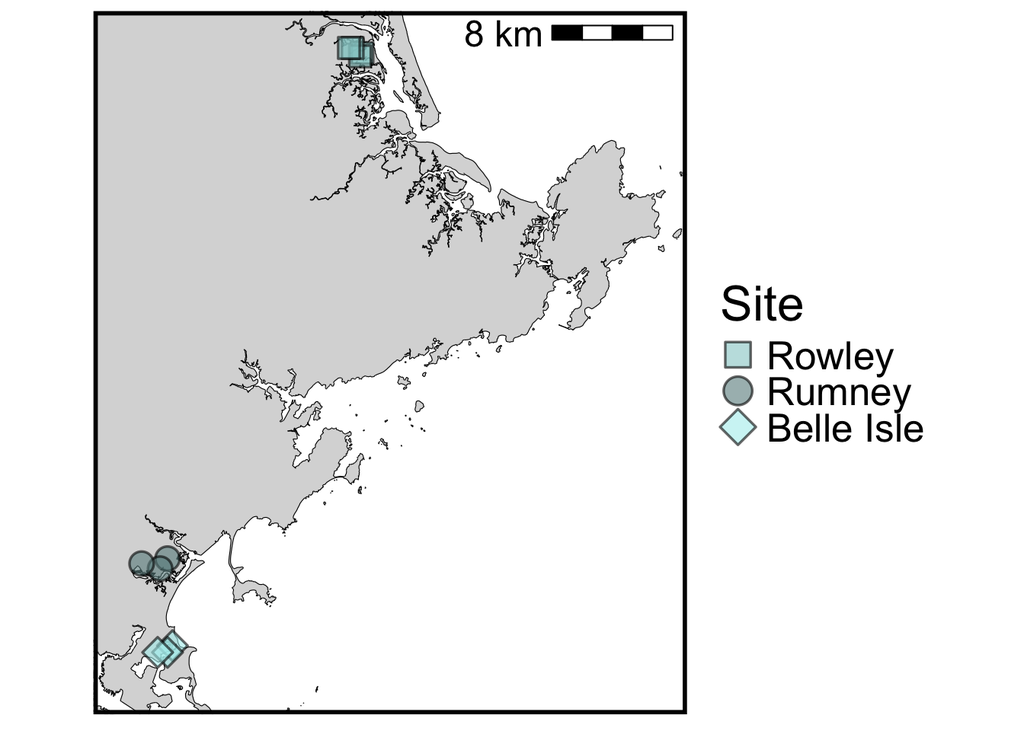

```r
# Source (or load) the generalized inset map function (this function should be in the same directory as the map_Hughes_EVA2026.Rmd)
source("inset_map_gen_func.R")
# You should see this function pop up in you environment once sourced. You can take a look at the function by clicking on it in your environment pop up.

# There are a few aesthetic values to define: set_shape_vals, set_fill_vals, set_fill_breaks

# assigning point shapes by site
set_shape_vals <- c("Rowley" = 22,
                    "Rumney" = 21,
                    "Belle Isle" = 23)

# assigning fill colors by site
set_fill_vals  <- c("Rowley" = "paleturquoise3",
                    "Rumney" = "paleturquoise4",
                    "Belle Isle" = "paleturquoise")
# order i want sites to appear for fill legend
set_fill_breaks <- c("Rowley",
                     "Rumney",
                     "Belle Isle")

# To adapt for a new study, replace the values above with your own sites, shapes, and colors!
# The function itself in the sourced R script does not need to change (unless you want to add axes back in or something like that...)

###############
# Full inset map
###############
inset_map_full <- inset_map_gen_func(
  long_range    = c(-71.05, -70.569), # set longitude range manually as desired; you can play with this as needed
  lat_range     = c(42.35, 42.77), # same for latitude
  pts_sf           = pts_ll, # sf points object of subsite locations for Hughes EVA 2026
  outline_poly  = ma_outline_poly, # MassGIS polygon shapefile
  outline_arc   = ma_outline, # MassGIS arc outline shapefile
  shape_col      = "site_shape", # name of column in pts_sf that determines shape
  shape_vals    = set_shape_vals, # vector with shapes values assigned to site_shape levels (defined above)
  fill_col      = "site_shape", # name of column in pts_sf that determines fill
  fill_vals     = set_fill_vals, # vector with fill color values assigned to site_shape levels (defined above)
  fill_breaks   = set_fill_breaks, # vector order in which I want the site_shape levels to appear in the fill legend (defined above)
  fill_name = "Site", # header name for the fill legend
  scale_bar_loc = "tr", # scale bar goes to topright
  scale_text_cex = 1.5 # can change size of scale bar text here
)

inset_map_full
```

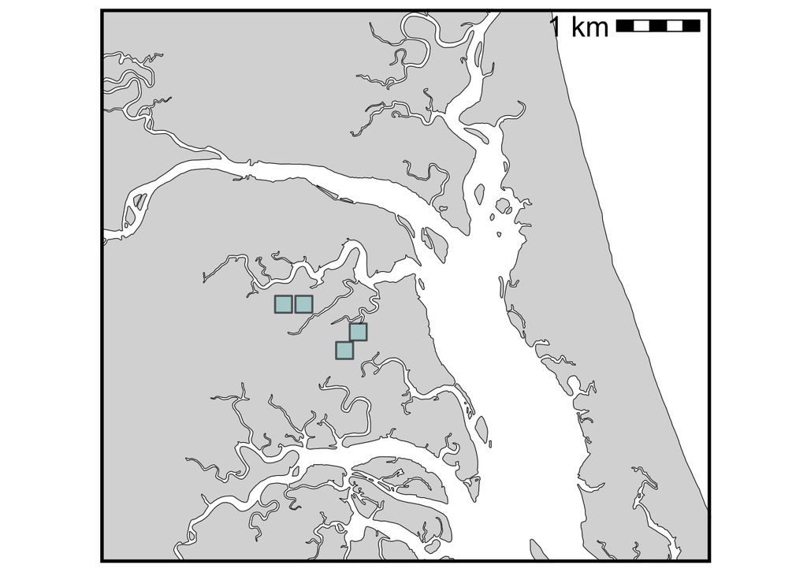

```r
###############
# ROWLEY inset map
###############

# use inset_map_func to generate the zoomed in inset with only the Rowley marsh subsites
# don't need to change the function to remove references to other sites aside from Rowley; rather, these points just don't appear because they are not included in the long and lat ranges provided for the Rowley zoomed inset

inset_map_row <- inset_map_gen_func(
  long_range = c(-70.87, -70.78), # changed to smaller range to center rowley
  lat_range = c(42.72, 42.78), # changed to smaller range to center rowley
  pts_sf           = pts_ll,
  outline_poly  = ma_outline_poly,
  outline_arc   = ma_outline,
  shape_col      = "site_shape",
  shape_vals    = set_shape_vals,
  fill_col      = "site_shape",
  fill_vals     = set_fill_vals,
  fill_breaks   = set_fill_breaks,
  fill_name = "Site",
  scale_bar_loc = "tr",
  scale_text_cex = 1.5) +
  theme(legend.position = "none") # took out legend here because going to add to full figure with legend in the inset_map_full; can remove this if you do want to keep site legend

inset_map_row
```

```r
# I also wanted to add subsite numbers to a version of this inset map to discern the subsite IDs
# printing subsites for Rowley here so you can cross-reference which site_num_1to9 corresponds to which named subsite when interpreting the numbered map below
data.frame(subsites_plot_locs)[data.frame(subsites_plot_locs)$site_shape == "Rowley", ]
```

```
##           species               site         subsite latitude longitude
## 1 S. alterniflora Rowley Great Marsh       Stackyard   42.745   -70.832
## 2       S. patens Rowley Great Marsh Stackyard South   42.743   -70.834
## 3 S. alterniflora Rowley Great Marsh          Patmos   42.748   -70.840
## 4 S. alterniflora Rowley Great Marsh           Law's   42.748   -70.843
##   date.of.seed.collection source.population.n greenhouse.population.n
## 1            Sept 27 2022                  20                      50
## 2            Sept 27 2022                  20                      50
## 3            Sept 27 2022                  20                      20
## 4            Sept 27 2022                  20                       0
##   species_used site_shape           subsite_display site_num site_num_1to9
## 1           SA     Rowley                 Stackyard        1             1
## 2           SP     Rowley Stackyard South (SP only)        4           3sp
## 3           SA     Rowley                    Patmos        3             2
## 4           SA     Rowley           Law's (SA only)        2           3sa
```

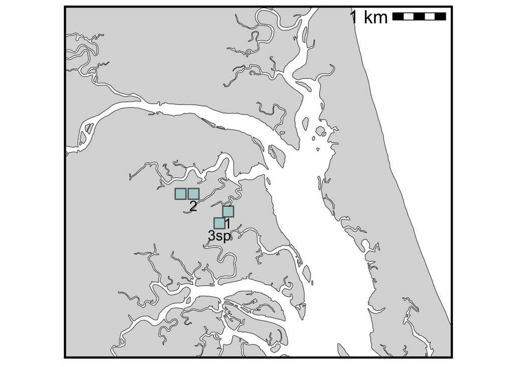

```r
# The subsite labels for rowley include two that are a bit long (3sa and 3sp). I'm adding labels except 3sa first, then will add 3sa in second at a slightly different position.
# Adding subsite labels without 3sa
inset_map_row_sitenums_no3sa <- inset_map_row + geom_sf_text( # this function will add points as text to map
  data = pts_ll[pts_ll$site_num_1to9 != "3sa",], # include all pts except 3sa
  aes(label = site_num_1to9), # use labels in column site_num_1to9
  size = 5, #size of points
  nudge_y = -0.002, # bump text up (positive) or down (negative) a tiny bit
  nudge_x = -0 # bump text right (positive) or left (negative) a tiny bit
)
# you may get a small warning message here about the precision of text placements in coordinate field...don't worry about it!
inset_map_row_sitenums_no3sa
```

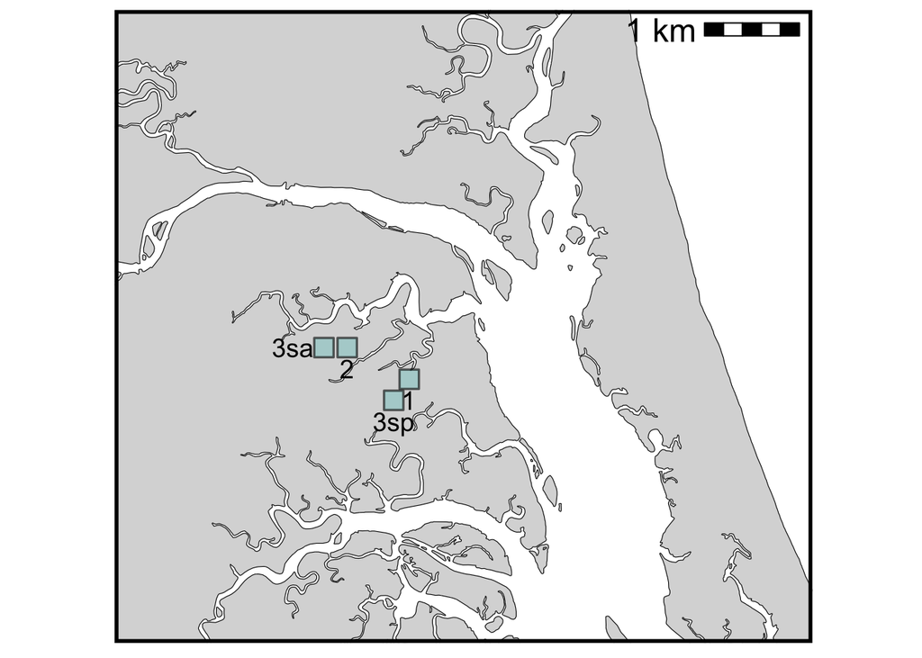

```r
inset_map_row_sitenums <- inset_map_row_sitenums_no3sa + geom_sf_text( # this function will add points to inset_map_ROW plot as text
  data = pts_ll[pts_ll$site_num_1to9 == "3sa",], #adding in 3sa pt only
  aes(label = site_num_1to9),
  size = 5,
  nudge_y = 0, # changed this so that it won't offset vertically
  nudge_x = -0.004 # made this more negative so that this label will appear further to left of point
)
inset_map_row_sitenums
```

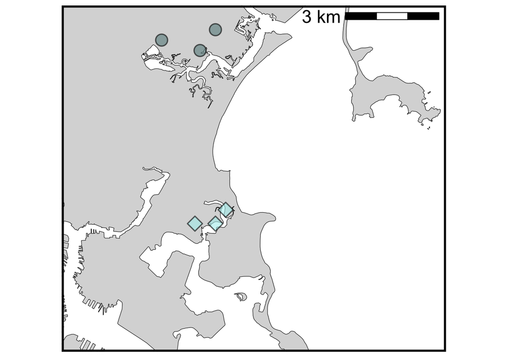

```r
# placement of labels still a bit awkward but good enough to discern subsite IDs now

###############
# RUMNEY and BELLE ISLE inset map
###############

# repeat the above for Rumney and Belle Isle; chose to map together because they are pretty close to each other...

inset_map_rumbel <- inset_map_gen_func(
  long_range = c(-71.05, -70.9), # now encompasses rumney and belle isle
  lat_range = c(42.35, 42.45), # now encompasses rumney and belle isle
  pts_sf           = pts_ll,
  outline_poly  = ma_outline_poly,
  outline_arc   = ma_outline,
  shape_col      = "site_shape",
  shape_vals    = set_shape_vals,
  fill_col      = "site_shape",
  fill_vals     = set_fill_vals,
  fill_breaks   = set_fill_breaks,
  fill_name = "Site",
  scale_bar_loc = "tr",
  scale_text_cex = 1.5) +
  theme(legend.position = "none")

inset_map_rumbel
```

```r
#add site numbers to a version of this map
data.frame(subsites_plot_locs)[data.frame(subsites_plot_locs)$site_shape != "Rowley", ]
```

```
##            species         site      subsite latitude longitude
## 5  S. alterniflora Rumney Marsh     Hamilton   42.443   -70.990
## 6  S. alterniflora Rumney Marsh          Far   42.437   -70.996
## 7  S. alterniflora Rumney Marsh      Terrace   42.440   -71.011
## 8  S. alterniflora   Belle Isle          Key   42.391   -70.986
## 9  S. alterniflora   Belle Isle       L-Berm   42.387   -70.990
## 10 S. alterniflora   Belle Isle Rosie's Pond   42.387   -70.998
##    date.of.seed.collection source.population.n greenhouse.population.n
## 5             Sept 15 2022                  20                      20
## 6             Sept 15 2022                  20                      20
## 7             Sept 15 2022                  20                      20
## 8             Sept 14 2022                  20                       0
## 9             Sept 14 2022                  20                       0
## 10            Sept 14 2022                  20                      20
##    species_used site_shape subsite_display site_num site_num_1to9
## 5            SA     Rumney        Hamilton        2             4
## 6            SA     Rumney             Far        1             5
## 7            SA     Rumney         Terrace        3             6
## 8            SA Belle Isle             Key        3             7
## 9            SA Belle Isle          L-Berm        1             8
## 10           SA Belle Isle    Rosie's Pond        2             9
```

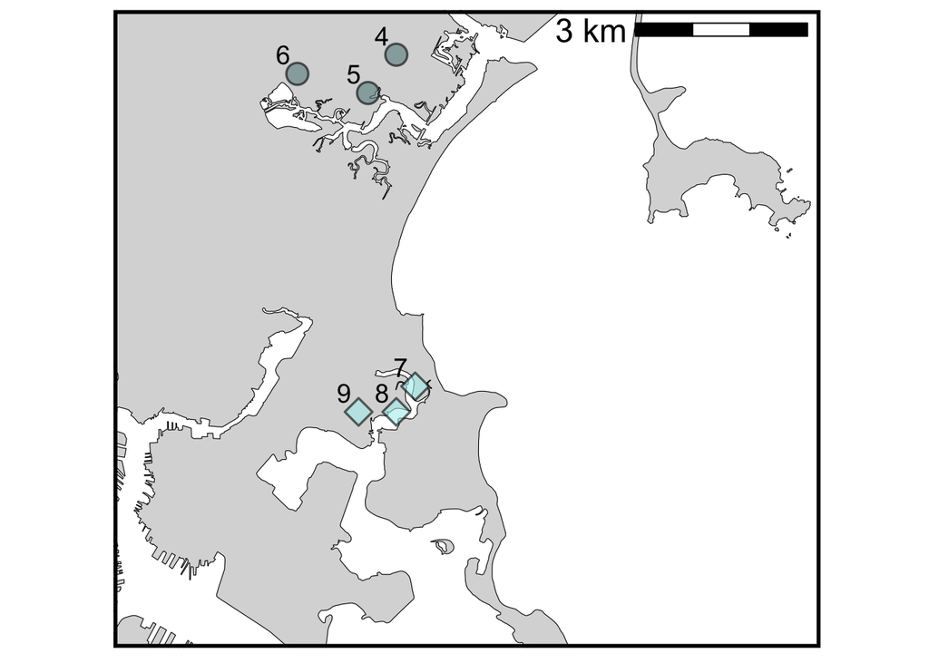

```r
inset_map_rumbel_sitenums <- inset_map_rumbel + geom_sf_text(
  data = pts_ll,
  aes(label = site_num_1to9),
  size = 5,
  nudge_y = 0.003,
  nudge_x = -0.003
)
inset_map_rumbel_sitenums
```

### B4. Write inset maps to map_figs output folder

```r
# saving plots as pdfs

ggsave(filename = file.path("map_figs","inset_map_full.pdf"),
       plot = inset_map_full,
       width = 6, height = 6)

ggsave(filename = file.path( "map_figs", "inset_map_row.pdf"),
       plot = inset_map_row,
       width = 6, height = 6)

ggsave(filename = file.path( "map_figs", "inset_map_rumbel.pdf"),
       plot = inset_map_rumbel,
       width = 6, height = 6)

ggsave(filename = file.path( "map_figs", "inset_map_row_sitenums.pdf"),
       plot = inset_map_row_sitenums,
       width = 6, height = 6)

ggsave(filename = file.path( "map_figs", "inset_map_rumbel_sitenums.pdf"),
       plot = inset_map_rumbel_sitenums,
       width = 6, height = 6)
```